# Project 1

### Connect to the Oracle Database

The following line of R code accesses an R file in the project and runs the code. The source code, *project1.R*, loads the RCurl package in order to be able to query data from the Oracle database then, the four tables are called and stored in data frames with their corresponding names.

```r
source("../01 Data/project1.R", echo=TRUE)
```

```
##
## > library("RCurl")
```

```
##
## > order_details <- data.frame(eval(parse(text = substring(getURL(URLencode("http://129.152.144.84:5001/rest/native/?query=\"select * from order_detail .... [TRUNCATED]
##
## > items <- data.frame(eval(parse(text = substring(getURL(URLencode("http://129.152.144.84:5001/rest/native/?query=\"select * from items\""),
## +     ht .... [TRUNCATED]
##
## > orders <- data.frame(eval(parse(text = substring(getURL(URLencode("http://129.152.144.84:5001/rest/native/?query=\"select * from orders\""),
## +      .... [TRUNCATED]
##
## > customers <- data.frame(eval(parse(text = substring(getURL(URLencode("http://129.152.144.84:5001/rest/native/?query=\"select * from customers\""),
##  .... [TRUNCATED]
```

### Display Data Frames

The loaded data frames are displayed using the *head()* function to show a few of the top entries for each data frame.

```r
source("../01 Data/displayDataframes.R", echo=TRUE)
```

```
##
## > head(customers)
##   CUSTOMER_ID CUSTOMER_FIRST_NAME CUSTOMER_LAST_NAME      CUSTOMER_ADDRESS
## 1           1               Korah             Blanca       1555 W Lane Ave
## 2           2                Yash            Randall 11 E Rancho Madera Rd
## 3           3           Johnathon          Millerton        60 Madison Ave
## 4           4             Mikayla             Damion      2021 K Street Nw
## 5           5             Kendall              Mayte 4775 E Miami River Rd
## 6           6             Kaitlin           Hostlery 3250 Spring Grove Ave
##   CUSTOMER_CITY CUSTOMER_STATE CUSTOMER_ZIP CUSTOMER_PHONE CUSTOMER_FAX
## 1      Columbus             OH        43221     6145554432   6145553920
## 2       Madison             WI        53707     2095551205   2095552262
## 3      New York             NY        10010     2125554800         NULL
## 4    Washington             DC        20006     2025555561         NULL
## 5        Cleves             OH        45002     5135553024         NULL
```

[output cut: 35 more lines]

### Interesting Plots

Each of the data frames is used to create a unique plot.

The customer city of the order is plotted agains the customer state. This provides a simple view of where the market of the albums resides. **Figure 1**

The unit price of the albums of each of the artists is displayed in a bar graph. The bar graph was accomplished by adding the geometric layer *+ geom_bar(stat=“identity”)* to the plotting parameters. **Figure 2**

The item id of each album is plotted against its corresponding order quantity as a bar graph. This allows for a simple comparison of the sales of each album. **Figure 3**

The number of days it takes for an order to ship after the order date is displayed by a bar graph. To do this, the days of shipped dates were subtracted from the days of order dates. The dates that ovelapped months were individually accounted for and adjusted manually. It certainly would have been easier to setup *if-then conditional* to automatically configure the negative dates. However, since the data was not too large it was just as easy to manually enter in the days. This plot displays how processing times for the album orders vary over the year. **Figure 4**

```
##
## > library(ggplot2)
##
## > market <- ggplot(customers, aes(x = CUSTOMER_STATE,
## +     y = CUSTOMER_CITY, color = CUSTOMER_ZIP)) + geom_point()
##
## > market + ggtitle("Markets of Albums\nFigure 1")
```

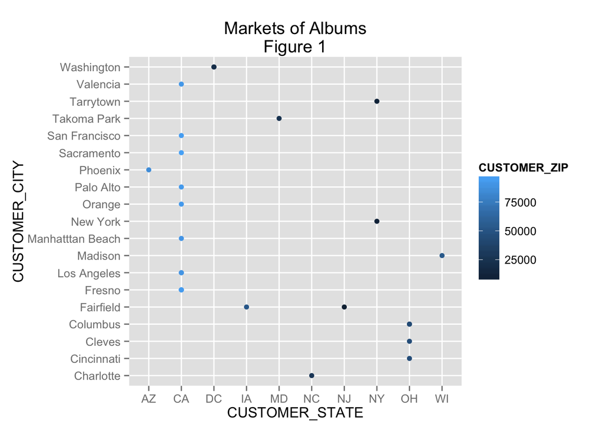

```
##
## > albumPrice <- ggplot(items, aes(x = as.factor(ARTIST),
## +     y = UNIT_PRICE)) + geom_bar(stat = "identity")
##
## > albumPrice + ggtitle("Album Prices\nFigure 2")
```

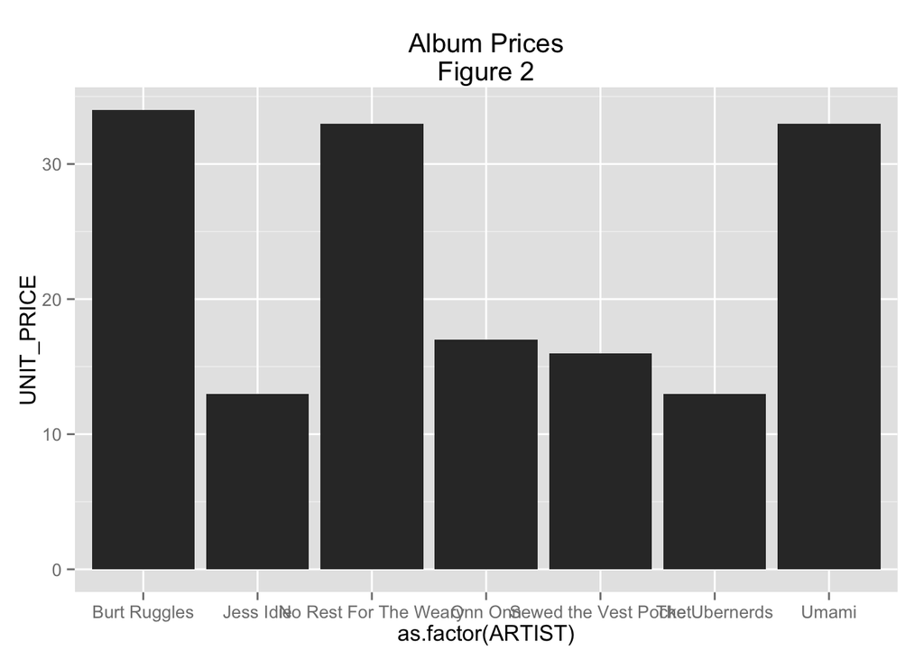

```
##
## > albumSales <- ggplot(order_details, aes(x = ITEM_ID,
## +     y = ORDER_QTY)) + geom_bar(stat = "identity")
##
## > albumSales + ggtitle("Album Sales\nFigure 3")
```

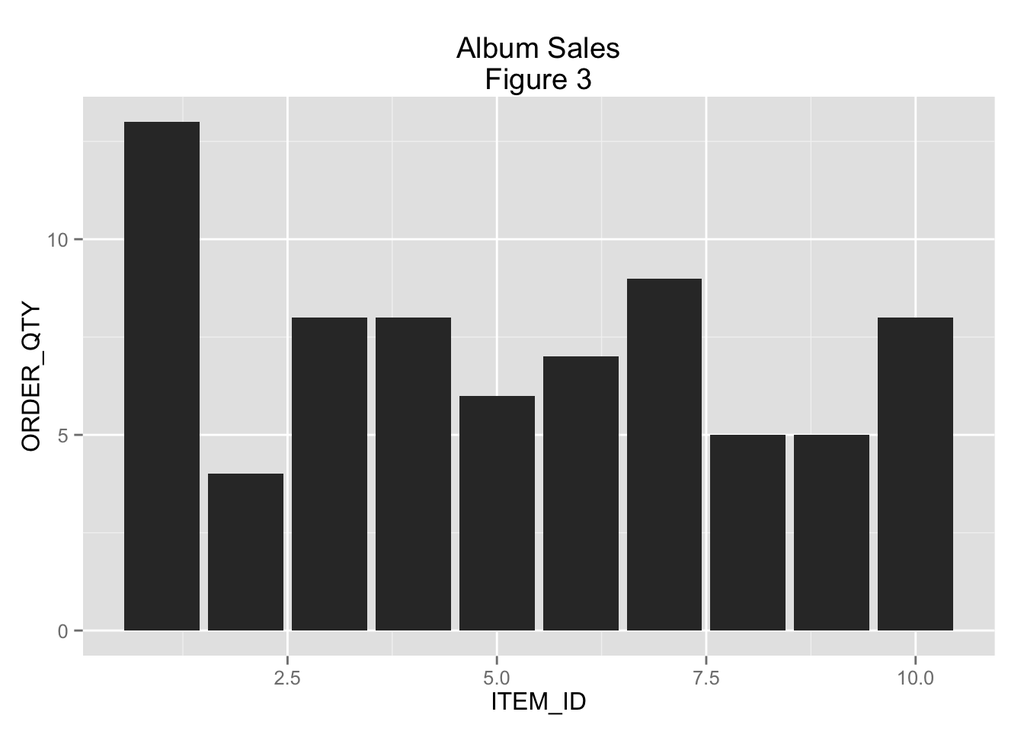

```
##
## > MONTHS <- as.numeric(substring(orders[, 3], 6, 7))
##
## > DAYS <- as.numeric(substring(orders[, 4], 9, 10)) -
## +     as.numeric(substring(orders[, 3], 9, 10))
##
## > DAYS[5] <- 10
##
## > DAYS[7] <- 4
##
## > DAYS[14] <- 12
##
## > DAYS[17] <- 26
##
## > DAYS[21] <- 6
##
## > DAYS[22] <- 32
##
## > DAYS[26] <- 26
##
## > DAYS[27] <- 10
##
## > DAYS[29] <- 9
##
## > DAYS[30] <- 9
##
## > DAYS[35] <- 13
##
## > DAYS[36] <- 9
##
## > DAYS[45:47] <- 0
##
## > shipTime <- ggplot(orders, aes(x = MONTHS, y = DAYS)) +
## +     geom_bar(stat = "identity")
##
## > shipTime + ggtitle("Album Shipping Time By Year\nFigure 4")
```

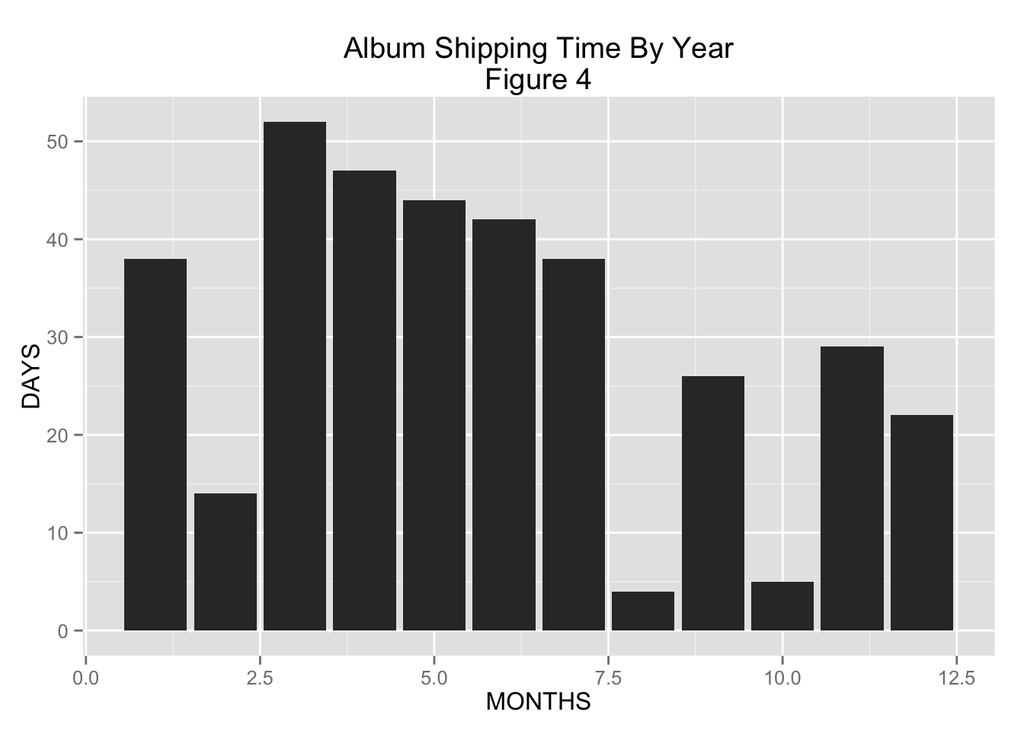

```r
source("../02 Visualizations/interestingPlots.R", echo=TRUE)
```

### Query

The following R code runs a query for the same data but joins all the columns together into one data frame. The head of the table is displayed.

```r
source("../02 Visualizations/entireJoin.R", echo=TRUE)
```

```
##
## > entire <- data.frame(eval(parse(text = substring(getURL(URLencode("http://129.152.144.84:5001/rest/native/?query=\"select * from orders o join custo .... [TRUNCATED]
##
## > head(entire)
##   ORDER_ID CUSTOMER_ID          ORDER_DATE        SHIPPED_DATE
## 1      550          17 2014-03-23 00:00:00 2014-04-03 00:00:00
## 2      298          18 2013-08-18 00:00:00 2013-09-22 00:00:00
## 3      242          23 2013-06-24 00:00:00 2013-07-06 00:00:00
## 4      829           9 2014-08-02 00:00:00                null
## 5       70          10 2012-12-28 00:00:00 2013-01-07 00:00:00
## 6      800          19 2014-07-21 00:00:00 2014-07-28 00:00:00
##   CUSTOMER_ID.1 CUSTOMER_FIRST_NAME CUSTOMER_LAST_NAME
## 1            17              Samuel           Jacobsen
## 2            18              Justin              Javen
## 3            23              Trisha               Anum
```

[output cut: 24 more lines]

### Reproduce Plots

To reproduce the given plots, the previous data frame that contains all the data was used. The values to plot were determined from the x- and y-axes labels of the given plots. The shipped dates of each order were plotted against the order dates using a dot plot and partitioned with respect to the states the orders came from. The partitioning was accomplished by adding *+facet_wrap(~CUSTOMER_STATE)* as a layer to the original plots.

The three plots display the same data. The only difference between them is the labeling of each data point. In the first plot, the unit price of the order determined the coloring of each data point, in the second, the title of the order, and in the third, the artist. The coloring scheme was added as an optional input of aesthetic mapping to the layer that creates the dot plot, *+ geom_point()*. The input was *aes(color=as.factor(**))*, where is the specific variable that defines how each data point is colored, as described above.

```
##
## > ggplot(entire, aes(x = as.Date(ORDER_DATE, "%Y-%m-%d"),
## +     y = as.Date(SHIPPED_DATE, "%Y-%m-%d"))) + geom_point(aes(color = as.factor(UNIT_PRICE .... [TRUNCATED]
```

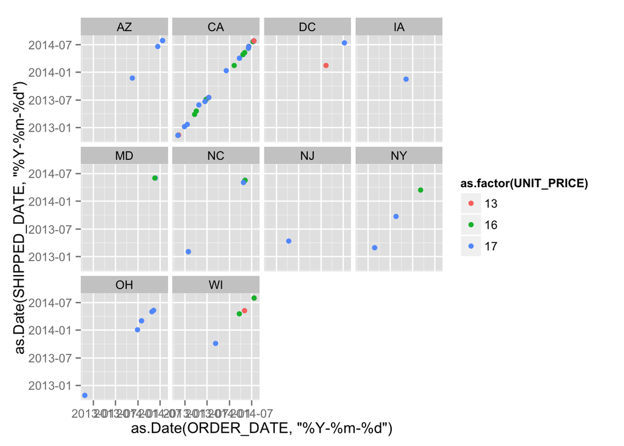

```
##
## > ggplot(entire, aes(x = as.Date(ORDER_DATE, "%Y-%m-%d"),
## +     y = as.Date(SHIPPED_DATE, "%Y-%m-%d"))) + geom_point(aes(color = as.factor(TITLE))) + .... [TRUNCATED]
```

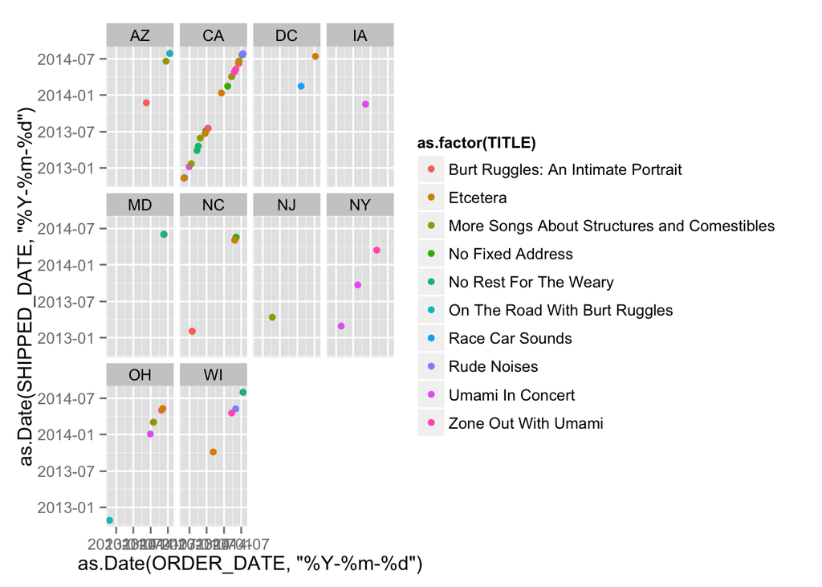

```
##
## > ggplot(entire, aes(x = as.Date(ORDER_DATE, "%Y-%m-%d"),
## +     y = as.Date(SHIPPED_DATE, "%Y-%m-%d"))) + geom_point(aes(color = as.factor(ARTIST)))  .... [TRUNCATED]
```

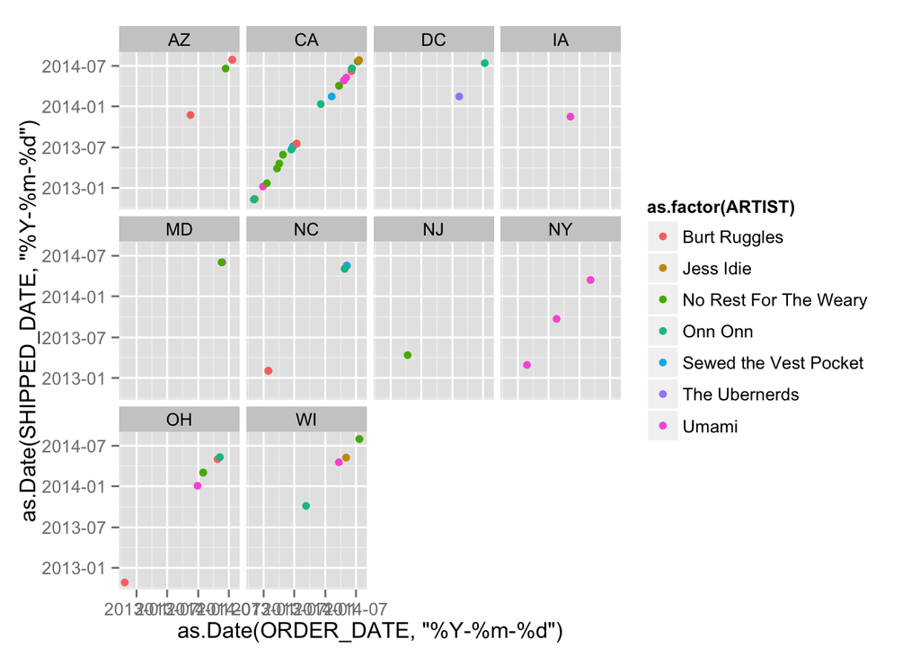

```r
source("../02 Visualizations/reproducedPlots.R", echo=TRUE)
```